# Transit Oriented Displacement? Has Minnesota’s Green Line Propagated Gentrification?

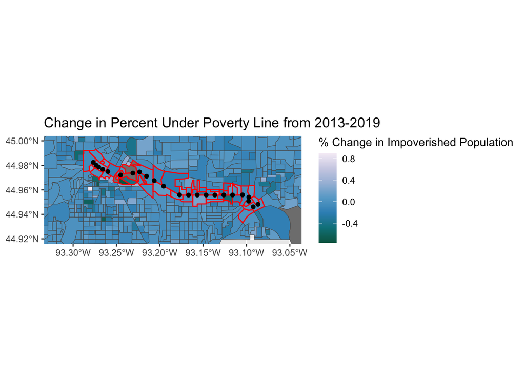

```r
stations %>%
  ggplot() +
  stat_sf_coordinates() +
  geom_sf(data = bothCounties, aes(fill = povertyChange)) +
  geom_sf(data= bothIntersect, alpha = 0, color = 'red', lwd = 0.5) +
  geom_sf() +
  scale_fill_distiller(palette = "PuBuGn",
                       name = "% Change in Impoverished Population") +
  xlim(c(-93.32, -93.05)) +
  ylim(c(44.92, 45)) +
  ggtitle("Change in Percent Under Poverty Line from 2013-2019") +
  theme(axis.title= element_blank())
```

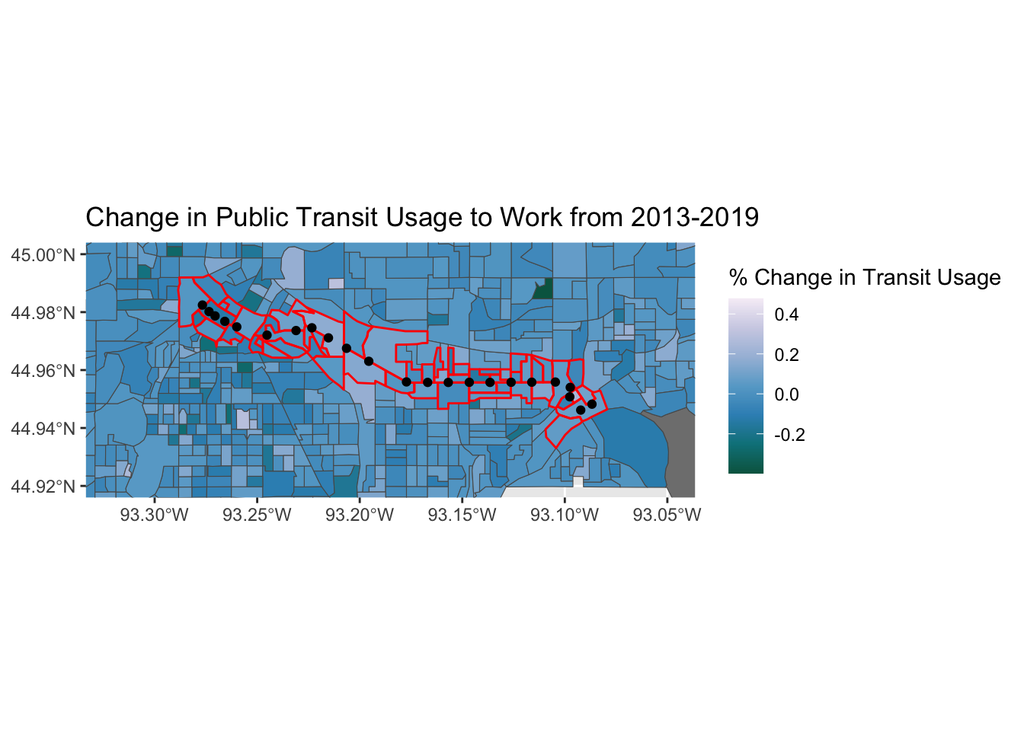

```r
stations %>%
  ggplot() +
  stat_sf_coordinates() +
  geom_sf(data = bothCounties, aes(fill = transitChange)) +
  geom_sf(data= bothIntersect, alpha = 0, color = 'red', lwd = 0.5) +
  geom_sf() +
  scale_fill_distiller(palette = "PuBuGn",
                       name = "% Change in Transit Usage") +
  xlim(c(-93.32, -93.05)) +
  ylim(c(44.92, 45)) +
  ggtitle("Change in Public Transit Usage to Work from 2013-2019") +
  theme(axis.title = element_blank())
```

Each visualization is intended to provide context to the numbers listed below

**calculating mean change and data analysis**

```r
allNumeric <- bothCounties[, sapply(bothCounties, is.numeric)] %>%
  st_drop_geometry()
meanAll <- colMeans(allNumeric %>% select(27:31), na.rm=TRUE)

intersectNumeric <- bothIntersect[, sapply(bothIntersect, is.numeric)] %>%
  st_drop_geometry()
meanIntersect <- colMeans(intersectNumeric %>% select(27:31), na.rm=TRUE)

meanAll
```

```
##         whiteChange       transitChange       povertyChange        incomeChange
##       -3.013768e-02       -1.233727e-03       -2.632521e-02        1.492580e+04
## propertyValueChange
##        4.137134e+04
```

```r
meanIntersect
```

```
##         whiteChange       transitChange       povertyChange        incomeChange
##       -2.454240e-03        1.668674e-02       -5.701691e-02        1.406432e+04
## propertyValueChange
##        4.255556e+04
```

White Percentage Change (Intersected Blocks vs. All): -0.25% vs. -3.01% Transit Usage Change (Intersected Blocks vs. All): 1.67% vs. -0.12% Poverty Change (Intersected Blocks vs. All): -5.70% vs. -2.63% $ Income Change (Intersected Blocks vs. All): 14,064 vs. 14,926 $ Property Value Change (Intersected Blocks vs. All): 42,556 vs. 41,371

I have not yet produced a way to statistically interpret these values/differences. For now I am simply remarking on what I believe are noticeable differences. There seems to be significant gaps between the change in both white population and poverty between Green Line adjacent block groups and the rest of the Twin Cities, with a greater rate of poverty decrease and smaller rate of white population decrease near the line, both potential signs of gentrification. This, however, is negated by a lower rate of income change and a negligibly higher rate of property value change. It is interesting, as well, to note that there is an increase in transit usage near the Green Line while overall usage decreases across the Twin Cities. This is not entirely a surprise though at least it validates the effectiveness of the development.

##Link to plan for rest of semester https://docs.google.com/document/d/1jpA_6du_PMXVgBpJa6N8YqCmpato0gwasjB6uNpM_xQ/edit